# Week 3 - Logistic Regression

This week I have worked with logistic regression. This week was full of many new concepts for me and I spent many hours on youtube watching “statquest” and “ritvikmath”’s videos on confusion matrices, loss functions and the like. Despite this large learning curve this week was enjoyable and I liked being able to begin to examine the predictive power of models!

```r
date()
```

```
## [1] "Tue Nov 22 00:04:18 2022"
```

# Assignment 3: Logistic Regression

### Relevant Libraries and Packages

```r
library(tidyverse)
library(dplyr)
library(ggplot2)
library(purrr)
library(knitr)
library(patchwork)
library(finalfit)
library(stringr)
library(caTools)
library(caret)
```

## Step 1: Reading in the Data

```r
# set working directory to access data
setwd("C:\\Users\\Emilia\\Documents\\Uni Helsinki\\Year One\\Teaching Period 2\\Open Data Science\\IODS-project_2022\\data")

# read data from previously wrangled file
alc_use <- read.csv("student_alc_use.csv", sep = ",", header = TRUE)
```

```r
# explore data structure
dim(alc_use)
```

```
## [1] 370  35
```

```r
str(alc_use)
```

```
## 'data.frame':    370 obs. of  35 variables:
##  $ school    : chr  "GP" "GP" "GP" "GP" ...
##  $ sex       : chr  "F" "F" "F" "F" ...
##  $ age       : int  18 17 15 15 16 16 16 17 15 15 ...
##  $ address   : chr  "U" "U" "U" "U" ...
##  $ famsize   : chr  "GT3" "GT3" "LE3" "GT3" ...
##  $ Pstatus   : chr  "A" "T" "T" "T" ...
##  $ Medu      : int  4 1 1 4 3 4 2 4 3 3 ...
##  $ Fedu      : int  4 1 1 2 3 3 2 4 2 4 ...
##  $ Mjob      : chr  "at_home" "at_home" "at_home" "health" ...
##  $ Fjob      : chr  "teacher" "other" "other" "services" ...
##  $ reason    : chr  "course" "course" "other" "home" ...
##  $ guardian  : chr  "mother" "father" "mother" "mother" ...
##  $ traveltime: int  2 1 1 1 1 1 1 2 1 1 ...
##  $ studytime : int  2 2 2 3 2 2 2 2 2 2 ...
```

[output cut: 21 more lines]

```r
# display column names
print(colnames(alc_use))
```

```
##  [1] "school"     "sex"        "age"        "address"    "famsize"
##  [6] "Pstatus"    "Medu"       "Fedu"       "Mjob"       "Fjob"
## [11] "reason"     "guardian"   "traveltime" "studytime"  "schoolsup"
## [16] "famsup"     "activities" "nursery"    "higher"     "internet"
## [21] "romantic"   "famrel"     "freetime"   "goout"      "Dalc"
## [26] "Walc"       "health"     "failures"   "paid"       "absences"
## [31] "G1"         "G2"         "G3"         "alc_use"    "high_use"
```

*Explanations*

Focusing on secondary students’ achievement at two schools in Portugal, this data set contains consisting of 35 variables with 370 observations. Originally, this data set consisted of two focusing on achievement in two subjects: math and Portuguese. These two sets were merged by the author and now contain combined information for each student’s achievement in each subject.

Information about these variables was collected using school reports and questionnaires the variables included are “student grades, demographic, social and school related features”. From the column names (seen above) it is clear that this data set covers these four aspects - with a special focus on social-related features. Variable types vary from integers, to numerical, character, and logical variables.

Additional attribute information can be found following: https://archive.ics.uci.edu/ml/datasets/Student+Performance

## Step 2: Hypotheses

### Variable 1: Going Out

The first hypothesis to be examined is based on the variable going out with friends. Essentially, my hypothesis is that those who go out with their friends more often will be more prone to high alcohol use. I assume that drinking alcohol is a social bonding activity and this is why those who go out more frequently are more likely to have higher use.

### Variable 2: Study Time

The second hypothesis is related to the variable study time. My hypothesis is that those who are studying more each week will have a lower chance of having high alcohol use. This hypothesis is purely based on my assumption that if you are spending the majority of your time studying, you will not have time to develop a high-use alcohol habit.

### Variable 3: Health

The third hypothesis relates to the health variable. As it could potentially exacerbate existing poor health I hypothesize that those with poor health are less likely to have high alcohol use.

### Variable 4: Sex

The final hypothesis focuses on the relationship between high alcohol use and sex. My hypothesis is that male students will have higher rates of alcohol use.

## Step 3: Numerical and Graphical Exploration

### Numerical

```r
keep_columns <- c("high_use",
                  "goout",
                  "studytime",
                  "health",
                  "sex"
                  )
alc_small <- select(alc_use, one_of(keep_columns))
```

```r
alc_small %>%
  split(.$high_use) %>%
  map(summary)
```

```
## $`FALSE`
##   high_use           goout         studytime         health
##  Mode :logical   Min.   :1.000   Min.   :1.000   Min.   :1.00
##  FALSE:259       1st Qu.:2.000   1st Qu.:2.000   1st Qu.:3.00
##                  Median :3.000   Median :2.000   Median :4.00
##                  Mean   :2.853   Mean   :2.162   Mean   :3.49
##                  3rd Qu.:3.000   3rd Qu.:3.000   3rd Qu.:5.00
##                  Max.   :5.000   Max.   :4.000   Max.   :5.00
##      sex
##  Length:259
##  Class :character
##  Mode  :character
##
##
##
##
## $`TRUE`
##  high_use           goout        studytime         health
##  Mode:logical   Min.   :1.00   Min.   :1.000   Min.   :1.00
##  TRUE:111       1st Qu.:3.00   1st Qu.:1.000   1st Qu.:3.00
##                 Median :4.00   Median :2.000   Median :4.00
##                 Mean   :3.73   Mean   :1.766   Mean   :3.73
##                 3rd Qu.:5.00   3rd Qu.:2.000   3rd Qu.:5.00
##                 Max.   :5.00   Max.   :4.000   Max.   :5.00
##      sex
##  Length:111
##  Class :character
##  Mode  :character
##
##
##
```

```r
dependent   <- "high_use"
explanatory <- c("goout","studytime", "health","sex")

alc_small %>%
  summary_factorlist(dependent, explanatory, p = TRUE,
                     add_dependent_label = TRUE)
```

```
##  Dependent: high_use                FALSE      TRUE      p
##                goout Mean (SD)  2.9 (1.0) 3.7 (1.1) <0.001
##            studytime         1  56 (21.6) 42 (37.8) <0.001
##                              2 128 (49.4) 57 (51.4)
##                              3  52 (20.1)   8 (7.2)
##                              4   23 (8.9)   4 (3.6)
##               health Mean (SD)  3.5 (1.4) 3.7 (1.4)  0.134
##                  sex         F 154 (59.5) 41 (36.9) <0.001
##                              M 105 (40.5) 70 (63.1)
```

*Interpretations*

From the numerical summaries we can see that those with high-use alcohol consumption are more likely to be male, go out more and spend less time studying. We can also see from the first summary table that there are 259 students who are not high-use and 111 who are.

It appears that those who go out more often are more likely to have higher alcohol consumption. This is confirmed in previous summary table the higher means present in the going out (3.73 for True, 2.853 for False). These results are significant at a p-value of p = <0.001.

As for study time, the majority of those with high alcohol use study below 5 hours a week (42 for under 2 hours and 57 for under 5 hours). We can also see this in mean summary with a 1.77 average for those with high-use and a 2.16 average for those who do not have high-use. These results are significant at p= <0.001.

With a p value of p = 0.134, the only non-statistically significant results are those related to health. It can be observed that there is not a large difference between those who did not drink 3.5 and those who did 3.7. Perhaps then, in the context of this data set, one’s health does not have a large effect on whether or not one drinks a lot.

Sex, as it is a character, was not covered in the first summary. However, in the second summary it can be observed that there males represent 63.1% of the high-use drinkers whereas females represent 36.9%. Rather intuitively these results are flipped with those who are not high-use. These results are significant at p= <0.001 which makes it significant at a 99% CI.

### Graphical

#### Box Plot

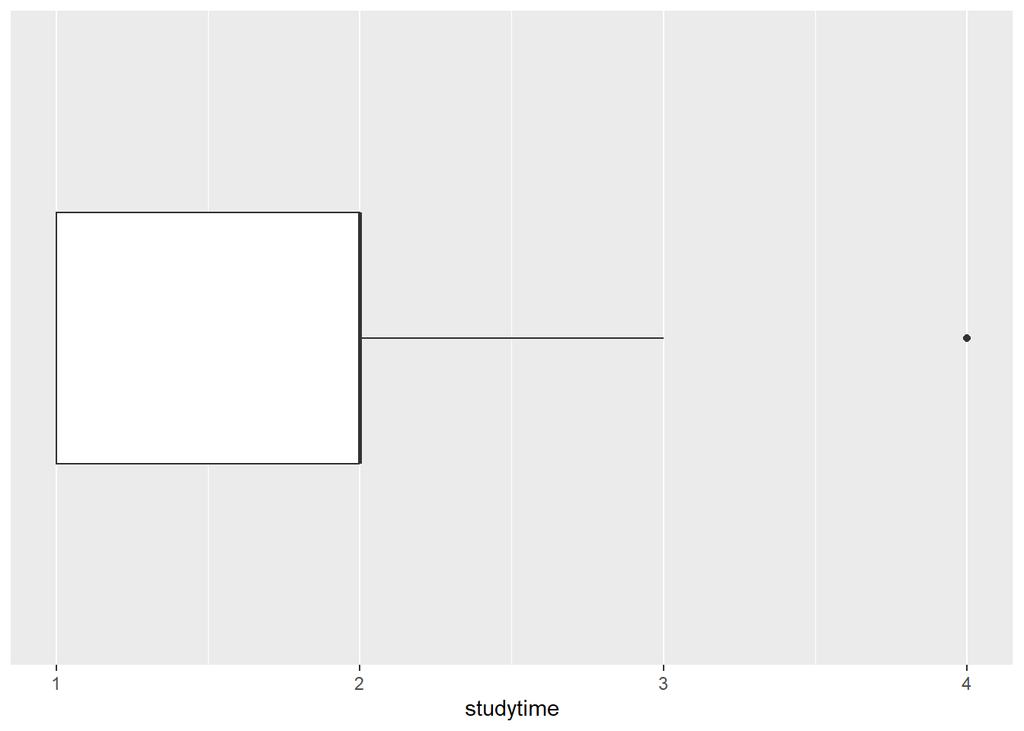

```r
alc_small %>%
  ggplot(aes(studytime)) +
  geom_boxplot() +
  scale_y_discrete(breaks = NULL, labels = NULL, name = NULL)
```

*Interpretations*

It appears as though the majority of students study between 1-5 hours a week (range of values 1 and 2). As for those who study above ten hours a week (value 4) it appears that these students are outliers in this dataset.

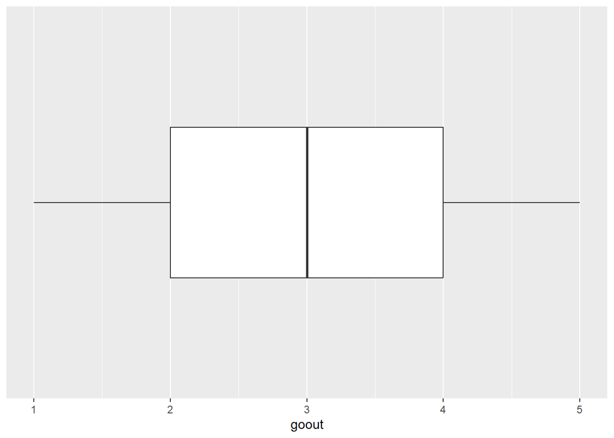

```r
alc_small %>%
  ggplot(aes(goout)) +
  geom_boxplot() +
  scale_y_discrete(breaks = NULL, labels = NULL, name = NULL)
```

*Interpretations*

Compared to the study time variable, it appears that the going out variable is normally distributed. The majority of students go out with their friends an average amount with the tails (very low and very high) following a normal bell curve.

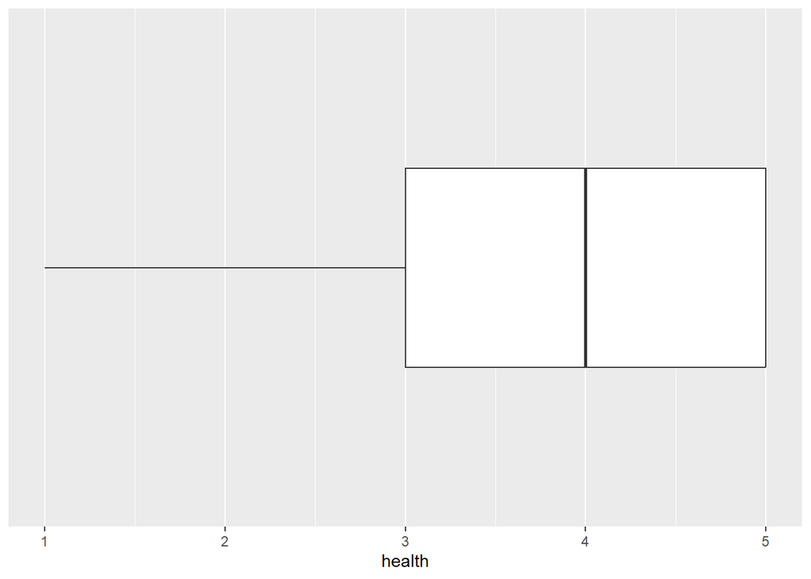

```r
alc_small %>%
  ggplot(aes(health)) +
  geom_boxplot() +
  scale_y_discrete(breaks = NULL, labels = NULL, name = NULL)
```

*Interpretations*

#### Count and Proportions

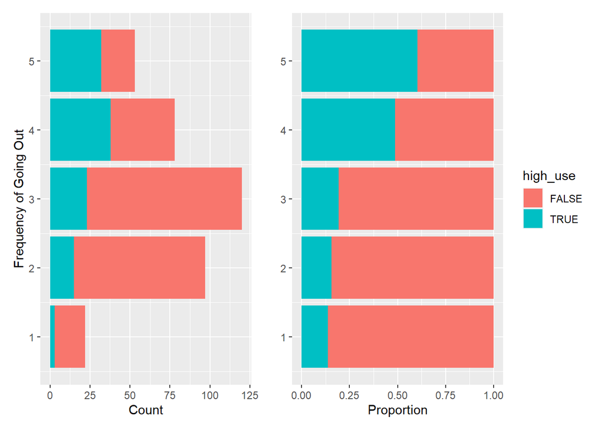

```r
p1 <- alc_small %>%
  ggplot(aes(x = goout,
             fill = high_use)) +
  geom_bar() +
  theme(legend.position="none")+
  coord_flip() +                               # flip for axis readability +
  labs(x = "Frequency of Going Out",           # label axes (flipped for coord-flip)
       y = "Count")

p2 <- alc_small %>%
  ggplot(aes(x = goout,
             fill = high_use,
             )) +
  geom_bar(position = "fill") +
  coord_flip() +                               # flip for axis readability
  theme(legend.position = NULL)+
  labs(x = "",                                 # label axes (flipped for coord-flip)
       y = "Proportion") +
  guides(fill = guide_legend(reverse = FALSE)) # reverse legend order

p1 + p2
```

*Interpretations*

From the proportion visualization, it is clear that those who are going out more often are more likely to have higher use of alcohol. A clear jump is seen between the frequency of 3 (average) and 4 (high). Perhaps this is because the majority of students answered that they see their friends an average amount and this large n evened out the results.

These results fall in line with my hypothesis that those students who go out more are have a higher probability of having higher levels of alcohol consumption.

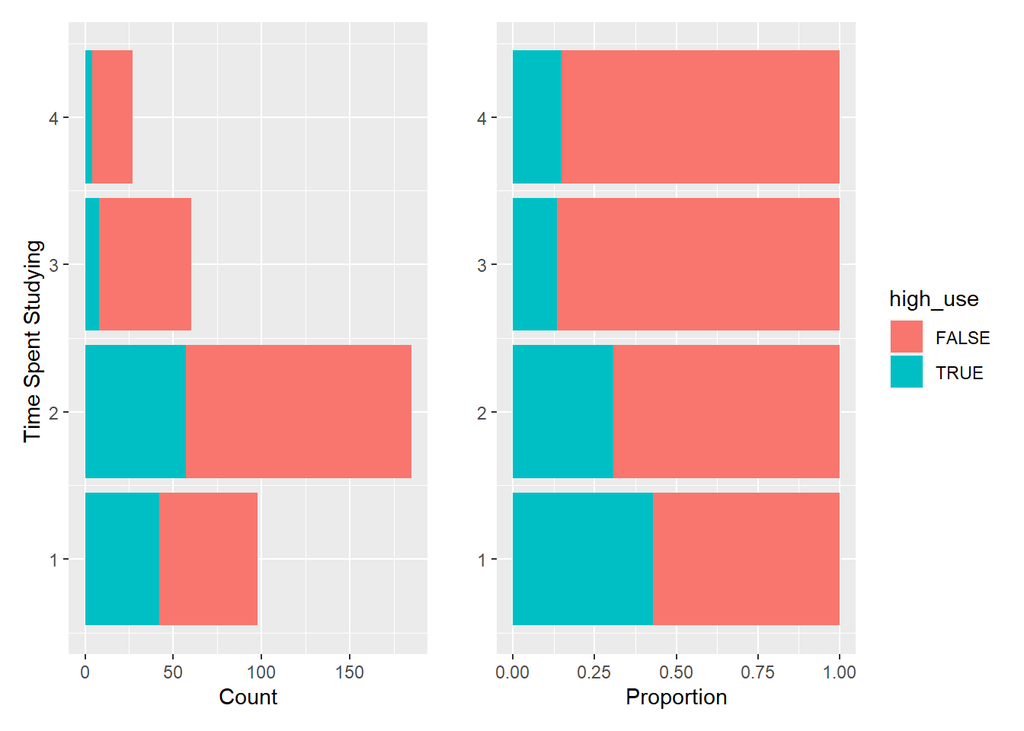

```r
p3 <- alc_small %>%
  ggplot(aes(x = studytime,
             fill = high_use)) +
  geom_bar() +
  theme(legend.position="none")+
  coord_flip() +                               # flip for axis readability +
  labs(x = "Time Spent Studying ",             # label axes (flipped for coord-flip)
       y = "Count")

p4 <- alc_small %>%
  ggplot(aes(x = studytime,
             fill = high_use,
             )) +
  geom_bar(position = "fill") +
  coord_flip() +                               # flip for axis readability
  theme(legend.position = NULL)+
  labs(x = "",                                 # label axes (flipped for coord-flip)
       y = "Proportion") +
  guides(fill = guide_legend(reverse = FALSE)) # reverse legend order

p3 + p4
```

*Interpretations*

Inverse to the going out variable, it appears that the more time one spends on one’s studies, the less likely one is to have higher levels of alcohol consumption. However, it should be noted that students who study more than 10 hours a week are outliers within this dataset and therefore the proportion is perhaps not representative.

These results align with my hypothesis that students who spent more time studying are less probable to consume alcohol at high levels.

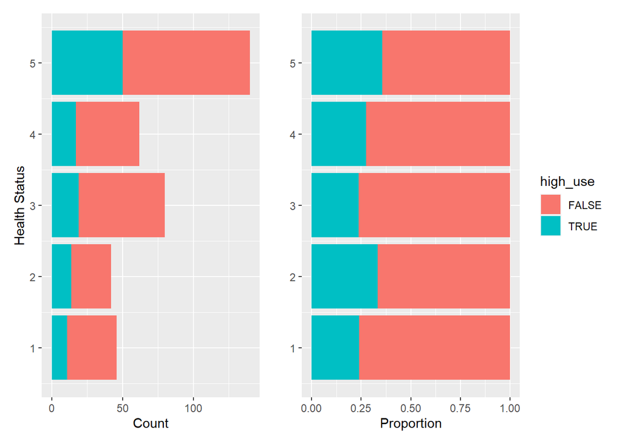

```r
p5 <- alc_small %>%
  ggplot(aes(x = health,
             fill = high_use)) +
  geom_bar() +
  theme(legend.position="none")+
  coord_flip() +                               # flip for axis readability +
  labs(x = "Health Status",                    # label axes (flipped for coord-flip)
       y = "Count")

p6 <- alc_small %>%
  ggplot(aes(x = health,
             fill = high_use,
             )) +
  geom_bar(position = "fill") +
  coord_flip() +                               # flip for axis readability
  theme(legend.position = NULL)+
  labs(x = "",                                 # label axes (flipped for coord-flip)
       y = "Proportion") +
  guides(fill = guide_legend(reverse = FALSE)) # reverse legend order

p5 + p6
```

*Interpretations*

Compared to the other two variables, health shows no trend when it comes to the relationship between health status and alcohol consumption. This makes sense as it was the only variable which did not possess a significant p-value (p=0.134).

These results do not fit my hypothesis as I thought that those with worse health (1 = very bad) would drink less than those with good health (5 = very good). Therefore, this hypothesis will be rejected.

#### Relationship

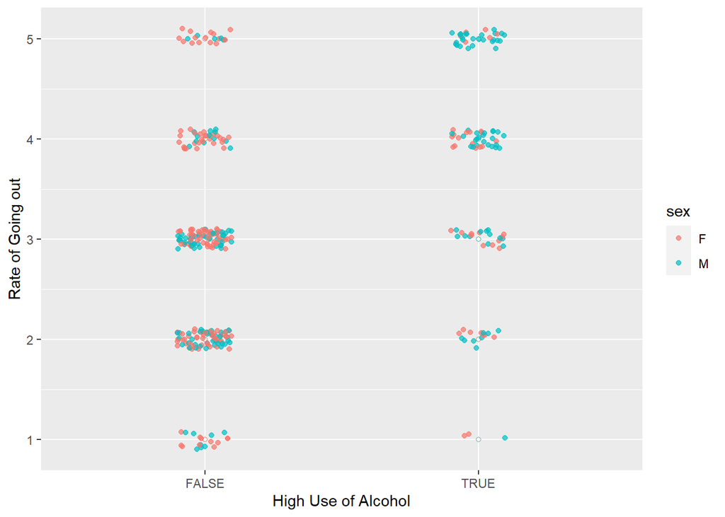

```r
p1 <- alc_small%>%
    ggplot(aes(x = high_use,
               y =goout,
               col = sex)) +
    geom_point(shape = 1, alpha = 0.5) +
    geom_jitter(width = 0.1, height = 0.1, alpha = 0.7) +
    labs(x = "High Use of Alcohol",
         y = "Rate of Going out")

p2 <- alc_small%>%
    ggplot(aes(x = high_use,
               y = studytime,
               col = sex)) +
    geom_point(shape = 1, alpha = 0.5) +
    geom_jitter(width = 0.1, height = 0.1, alpha = 0.7) +
    labs(x = "High Use of Alcohol",
         y = "Time Spent Studying")
p3 <- alc_small%>%
      ggplot(aes(x = high_use,
                 y = health,
                 col = sex)) +
      geom_jitter(width = 0.1, height = 0.1, alpha = 0.7) +
      labs(x = "High Use of Alcohol",
           y = "Current Health Condition")

p1
```

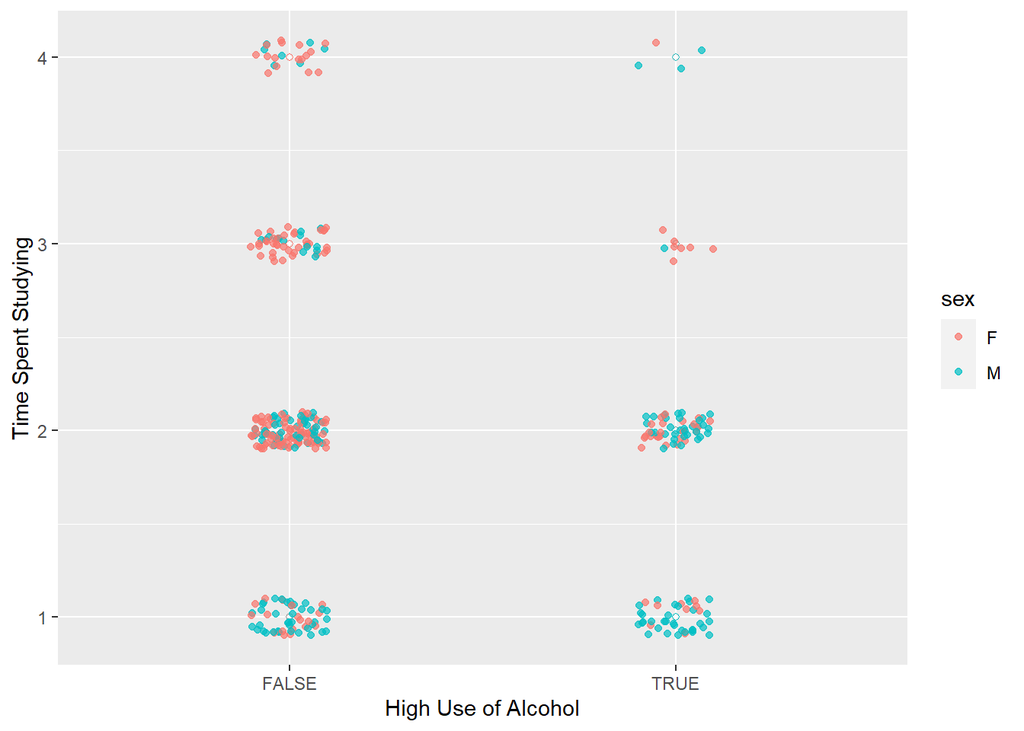

```r
p2
```

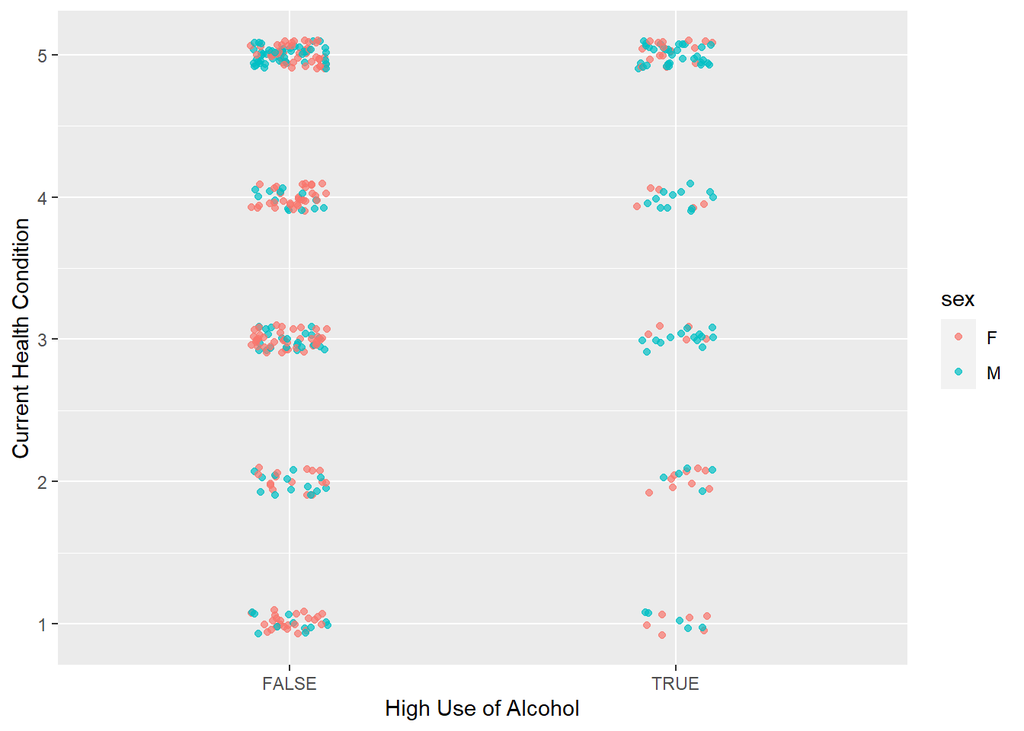

```r
p3
```

*Interpretations*

Like the above visualizations, this one confirms the hypotheses regarding going out and study time, but rejects the third related to health. These hypotheses are confirmed through observing the clustering of points. As this visualization adds the sex dimension, it is interesting to see if any observations regarding the relationship between alcohol use and sex can be made.

From the rate of going out visualization it appears to be that those who have high-use and go out very often are largely male. This can also be observed in the group of those who go out quite often. For the second visualization, it appears that those who study less than two hours a week and have a high-use are more likely to be male. Finally, for the third visualization no clear patterns in sex are present.

Due to over-fitting it is quite hard to see from this visualization what role sex might play in high alcohol use. Therefore, I will move on to the logistic regression section of this report to examine this hypothesis in more detail.

## Step 4: Logistic Regression

### Model Creation

```r
model1 <- glm(high_use ~ goout + studytime + health + sex, data = alc_small, family = "binomial")
```

### Model Summary

```r
summary(model1)
```

```
##
## Call:
## glm(formula = high_use ~ goout + studytime + health + sex, family = "binomial",
##     data = alc_small)
##
## Deviance Residuals:
##     Min       1Q   Median       3Q      Max
## -1.7958  -0.8199  -0.5074   0.8266   2.6553
##
## Coefficients:
##             Estimate Std. Error z value Pr(>|z|)
## (Intercept) -3.08085    0.66722  -4.617 3.88e-06 ***
## goout        0.75535    0.11995   6.297 3.03e-10 ***
## studytime   -0.49173    0.16972  -2.897  0.00376 **
## health       0.10173    0.09144   1.113  0.26588
## sexM         0.67717    0.26542   2.551  0.01073 *
## ---
## Signif. codes:  0 '***' 0.001 '**' 0.01 '*' 0.05 '.' 0.1 ' ' 1
##
## (Dispersion parameter for binomial family taken to be 1)
##
##     Null deviance: 452.04  on 369  degrees of freedom
## Residual deviance: 378.52  on 365  degrees of freedom
## AIC: 388.52
##
## Number of Fisher Scoring iterations: 4
```

*Interpretations*

From the coefficients we can see that the effect of going out on high alcohol use is an increase in the risk for high-alcohol use with the more on goes out (0,75535). For study time, as it is negative coefficient, for each increase in time spent studying there will be a reduction in the risk for high alcohol use (-0.49173). As for health, there is no significant effect. Finally, for sex, if the sex is male it will result in a risk increase (0.67717).

### Coefficients and Odds Ratios

```r
# compute odds ratios (OR)
OR <- coef(model1) %>% exp

# compute confidence intervals (CI)
CI <- confint(model1) %>% exp
# print out the odds ratios with their confidence intervals
cbind(OR, CI)
```

```
##                     OR      2.5 %    97.5 %
## (Intercept) 0.04592009 0.01197811 0.1648997
## goout       2.12835997 1.69321221 2.7127268
## studytime   0.61156896 0.43389780 0.8459784
## health      1.10708915 0.92679412 1.3275397
## sexM        1.96828985 1.17240926 3.3264016
```

*Interpretations*

Below, the odds ratio and the confidence interval difference can be seen. The confidence interval difference represents the range which is represented within the 95% confidence interval.

| Variable | OR | Confidence Interval Difference |
| --- | --- | --- |
| Going out | 2.13 | 1.02 (1.01951459) |
| Study Time | 0.61 | 0.41 (0.4120806) |
| Health | 1.11 | 0.40 (0.40074558) |
| Sex | 1.97 | 2.15 (2.15400134) |

## Step 5: Predictive power

Using the variables which, according to your logistic regression model, had a statistical relationship with high/low alcohol consumption, explore the predictive power of you model.

#### Model Creation

```r
final_model <- glm(high_use ~ goout + studytime + sex, data = alc_small, family = "binomial")
```

Provide a 2x2 cross tabulation of predictions versus the actual values and optionally display a graphic visualizing both the actual values and the predictions.

#### Cross tabulations: Predicted vs Actual

##### Numerical

```r
# predict() the probability of high_use
probabilities <- predict(final_model, type = "response")

# add the predicted probabilities to 'alc_small'
alc_small <- mutate(alc_small, probability = probabilities)

# use the probabilities to make a prediction of high_use
alc_small <- mutate(alc_small, prediction = alc_small$probability > 0.5)

# tabulate the target variable versus the predictions
table(high_use = alc_small$high_use, prediction = alc_small$prediction)
```

```
##         prediction
## high_use FALSE TRUE
##    FALSE   234   25
##    TRUE     58   53
```

##### Total Training Error

proportion = `(false positive + false negative)/n`

proportion = `(25 + 58)/370`

proportion = 0.2243

```r
confusionMatrix(
  factor(alc_small$prediction),
  factor(alc_small$high_use))
```

```
## Confusion Matrix and Statistics
##
##           Reference
## Prediction FALSE TRUE
##      FALSE   234   58
##      TRUE     25   53
##
##                Accuracy : 0.7757
##                  95% CI : (0.7297, 0.8172)
##     No Information Rate : 0.7
##     P-Value [Acc > NIR] : 0.0006928
##
##                   Kappa : 0.4163
##
##  Mcnemar's Test P-Value : 0.0004440
##
##             Sensitivity : 0.9035
##             Specificity : 0.4775
##          Pos Pred Value : 0.8014
##          Neg Pred Value : 0.6795
##              Prevalence : 0.7000
##          Detection Rate : 0.6324
##    Detection Prevalence : 0.7892
##       Balanced Accuracy : 0.6905
##
##        'Positive' Class : FALSE
##
```

*Interpretations*

Although I am not at the point where I can interpret the other outputs (Kappa, Sensitivity etc.), I hope to reach there one day!

##### Graphical

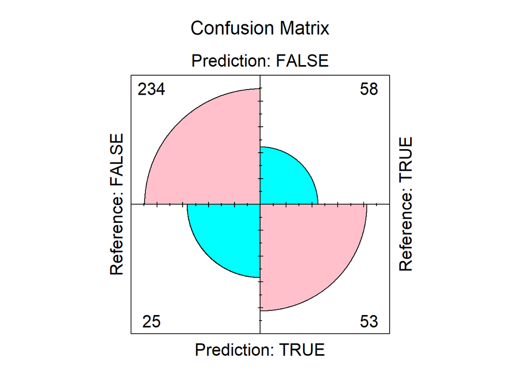

```r
# create confusion matrix
cmat <- confusionMatrix(
  factor(alc_small$prediction),
  factor(alc_small$high_use))

# visualize confusion matrix
fourfoldplot(cmat$table, color = c("cyan", "pink"),
             conf.level = 0, margin = 1, main = "Confusion Matrix")
```

*Final Interpretations and Model/Hypotheses Comparison*

A generous reading of the confusion matrix and the performance of the model would say that the model predicts false values correctly 9/10 of the time and positive values correctly 1/2 of the time. I do not believe that my simple guessing strategies would be able to reach this level of accuracy. When guessing, I often rely on broad generalizations (those who go out must drink more) to reach my conclusions. My hypotheses were thus oversimplified and did not reveal the nuance in the data. A clear example was that those who go out often have a 50% chance of having high alcohol use or not. Therefore, in order to reach the model accuracy, I would need to take more factors into account during my guessing. Yes, it is true that male students do drink more but is how much they drink proportionally to their weight taken into account? Therefore, while a simple guessing strategy can perhaps point the researcher which way to look, I do not think it can predict results as accurately as a well-built model can.